# RR Project 1

Moein Mahmoudi

2023-02-20

In order to answer our questions, first we read the data “activity.csv” into a data frame, which we call “Activity”

```r
library(tidyverse)
Activity <- data.frame(read.csv(file = "./activity.csv"))
```

Then we group data frame by “date” variable and calculate:  
Total number of steps taken each day and a histogram of this value over time

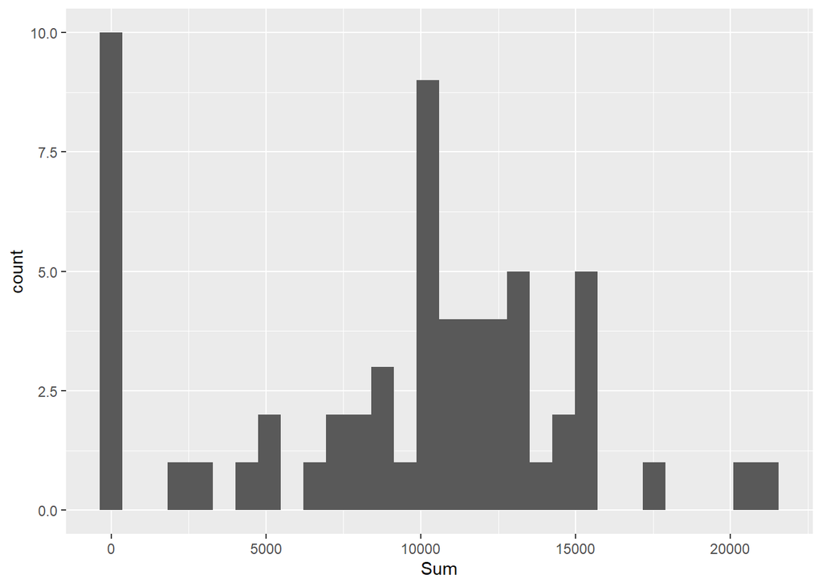

```r
daily_total <- Activity |>
                group_by(date) |>
                summarise(Total_Steps <- sum(steps, na.rm = TRUE))

colnames(daily_total) <- c("Date", "Sum")

ggplot(data = daily_total)+
  geom_histogram(aes(x = Sum))
```

```r
total_mean <- mean(daily_total$Sum) ; total_median <- median(daily_total$Sum)
```

Mean and Median of total number of steps

```r
total_mean ;
```

```
## [1] 9354.23
```

```r
total_median
```

```
## [1] 10395
```

Then we group data frame by time interval variable and plot a time series of steps in each interval.

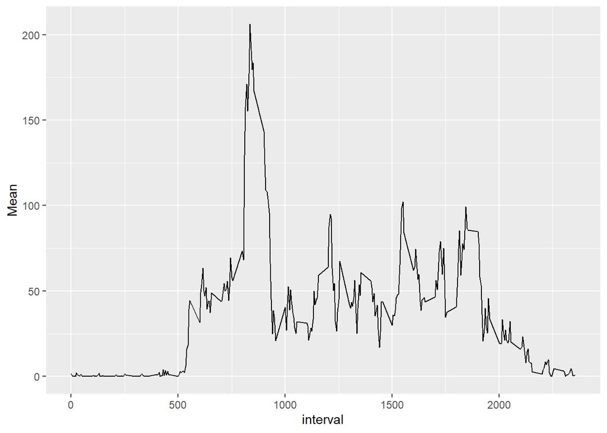

```r
interval_mean <- Activity |>
  group_by(interval) |>
  summarise(Mean = round(mean(steps,na.rm = TRUE),digits = 2))

# time series plot of time intervals and steps
ggplot(data = interval_mean)+
  geom_line(aes(x = interval, y = Mean))
```

We also we can report the time interval in which the maximum steps have been taken:

```r
# interval with maximum steps
interval_mean[which.max(interval_mean$Mean),]$interval
```

```
## [1] 835
```

Total number of NA values in steps:

```r
nrow(Activity[Activity$steps == "NA",])
```

```
## [1] 2304
```

To tackle the problem of NAs, we copy a data frame exactly same to the original data frame, but we add a variable Mean_Steps to it. The variable is the average of steps in each time interval and we replicate it 61 times for all days. Then we replace the value of *steps* for each row that is same to NA with this variable.

```r
Activity_NA <- Activity
Activity_NA$Mean_Steps <- rep(interval_mean$Mean, 61)
Activity_NA[is.na(Activity_NA$steps),]$steps <-
  Activity_NA[is.na(Activity_NA$steps),]$Mean_Steps
```

Then we repeat the calculations for daily number of steps histogram and its mean and median:

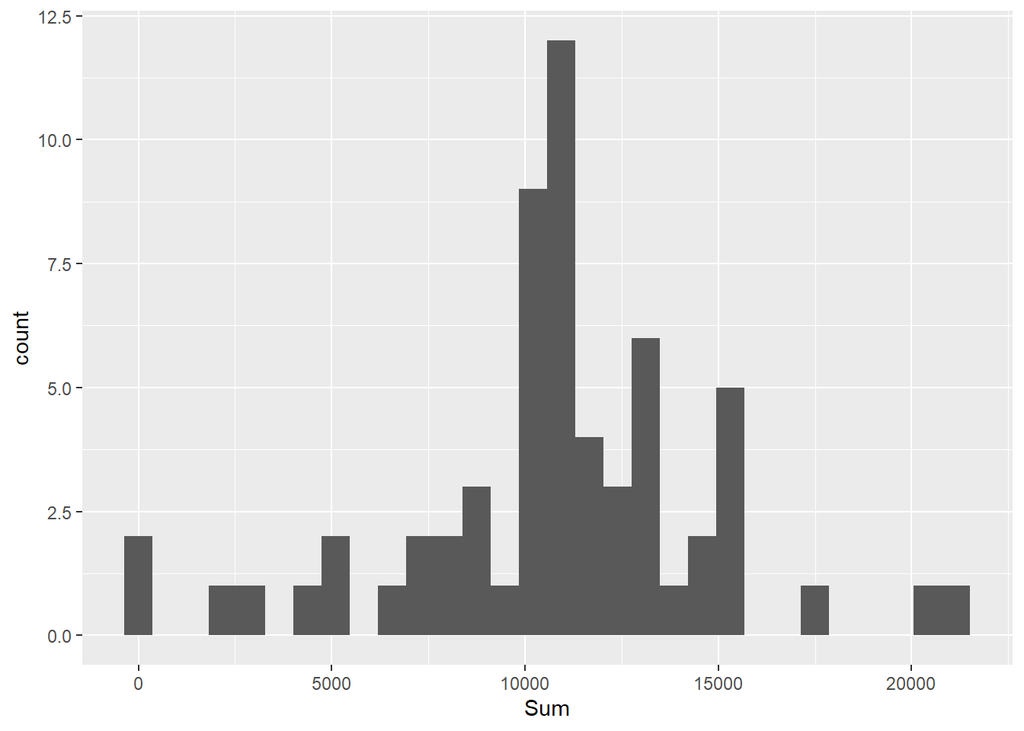

```r
daily_total_NA <- Activity_NA |>
  group_by(date) |>
  summarise(Total_Steps <- sum(steps, na.rm = TRUE))

colnames(daily_total_NA) <- c("Date", "Sum")

ggplot(data = daily_total_NA)+
  geom_histogram(aes(x = Sum))
```

```r
total_mean_NA <- mean(daily_total_NA$Sum)
total_median_NA <- median(daily_total_NA$Sum)
```

As we see, there is a difference between before and after of this replacement:

```r
c(total_mean , total_mean_NA, total_median, total_median_NA)
```

```
## [1]  9354.23 10766.18 10395.00 10766.13
```

In the next section, we make a new variable to segregate weekends and working days of the week through the weekdays() function.

```r
# convert character to date
Activity_NA$New_Date <- as.Date(Activity_NA$date)
# applying function of weekdays
Activity_NA$Day <- weekdays(Activity_NA$New_Date)
# make a new variable
Activity_NA$Type_of_Day <- "NA"
# define weekends and weekdays
Activity_NA[Activity_NA$Day == "Saturday",]$Type_of_Day <- "Weekends"
Activity_NA[Activity_NA$Day == "Sunday",]$Type_of_Day <- "Weekends"
Activity_NA[Activity_NA$Type_of_Day != "Weekends",]$Type_of_Day <- "Weekdays"
Activity_NA$Type_of_Day <- as.factor(Activity_NA$Type_of_Day)
```

For the last plot, at first, we calculate average of steps taken by time intervals separately for weekends and weekdays, then we join them together in “interval_means” data frame:

```r
interval_mean_Weekdays <- Activity_NA[Activity_NA$Type_of_Day == "Weekdays",] |>
  group_by(interval) |>
  summarise(Mean = round(mean(steps,na.rm = TRUE),digits = 2))

interval_mean_Weekends <- Activity_NA[Activity_NA$Type_of_Day == "Weekends",] |>
  group_by(interval) |>
  summarise(Mean = round(mean(steps,na.rm = TRUE),digits = 2))

interval_means <- data.frame(interval_mean_Weekdays$interval,
                             interval_mean_Weekdays$Mean ,
                             interval_mean_Weekends$Mean)

colnames(interval_means) <- c("Interval", "Weekdays_Mean", "Weekends_Mean")
```

And finally plot the requested plot through ggplot():

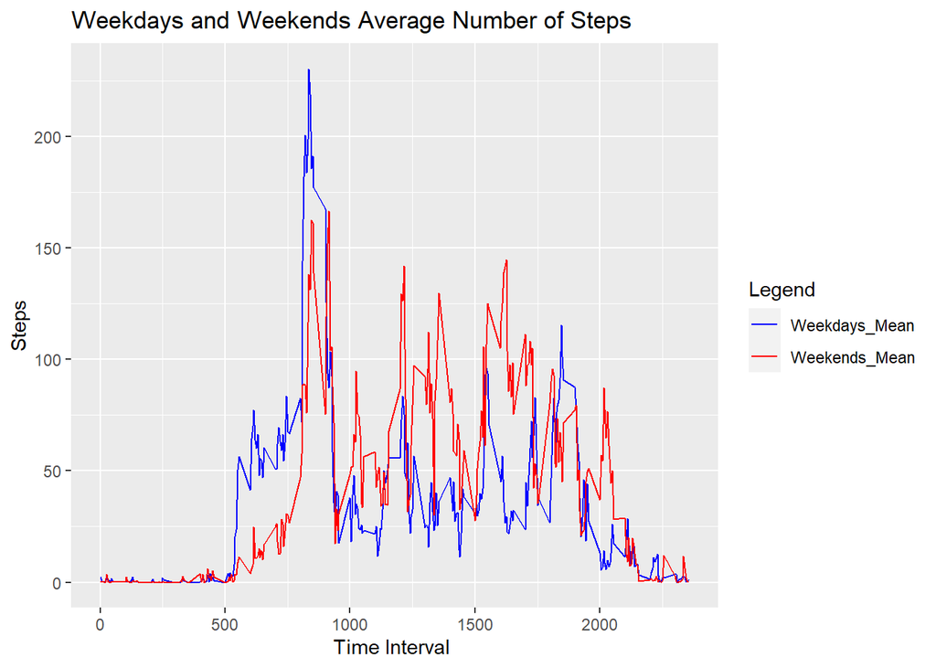

```r
colors <- c("Weekdays_Mean" = "blue", "Weekends_Mean" = "red")

ggplot(interval_means, aes(x = Interval)) +
    geom_line(aes(y = Weekdays_Mean, color = "Weekdays_Mean"), size = .5) +
    geom_line(aes(y = Weekends_Mean, color = "Weekends_Mean"), size = .5) +
    labs(title = "Weekdays and Weekends Average Number of Steps",
       x = "Time Interval ",
       y = "Steps",
       color = "Legend") +
    scale_color_manual(values = colors)
```